# Assignment 4

Neil Noyes

9/12/2020

## 1 :: Return to the `iris` data set included in R. Examine the distributions of `Sepal.Length` and `Sepal.Width`. Produce a graph (or two) which represent these distributions.

```r
library(tidyverse)
```

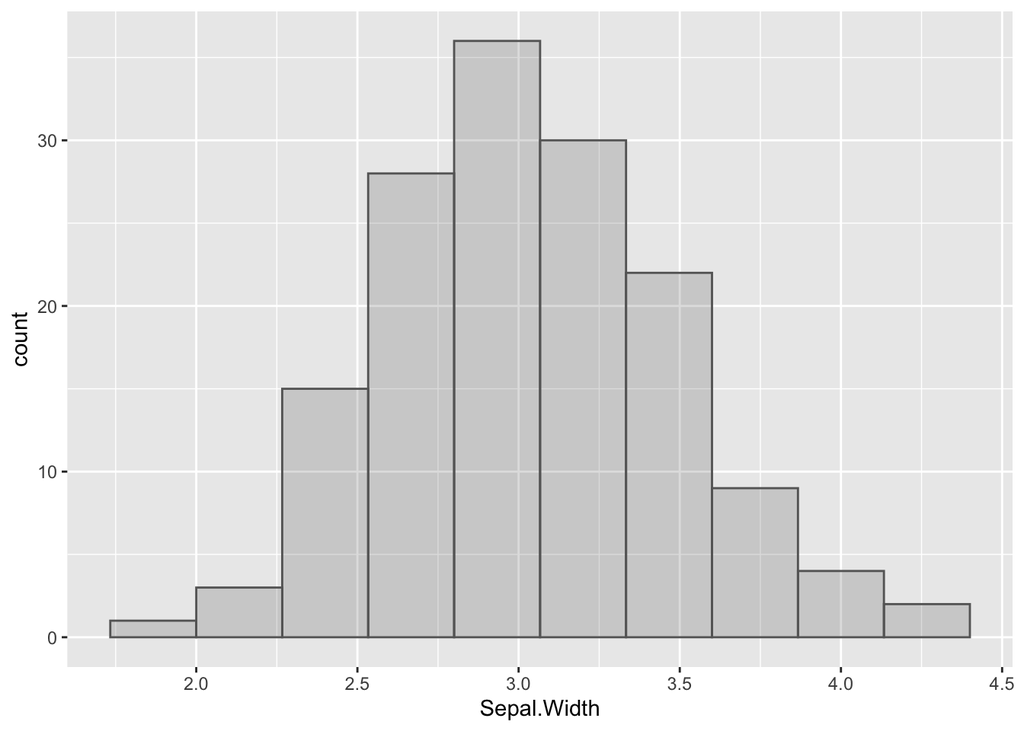

```r
iris %>%
  ggplot(aes(x = Sepal.Width)) +
  geom_histogram(position="identity", colour="grey40", alpha=0.2, bins = 10)
```

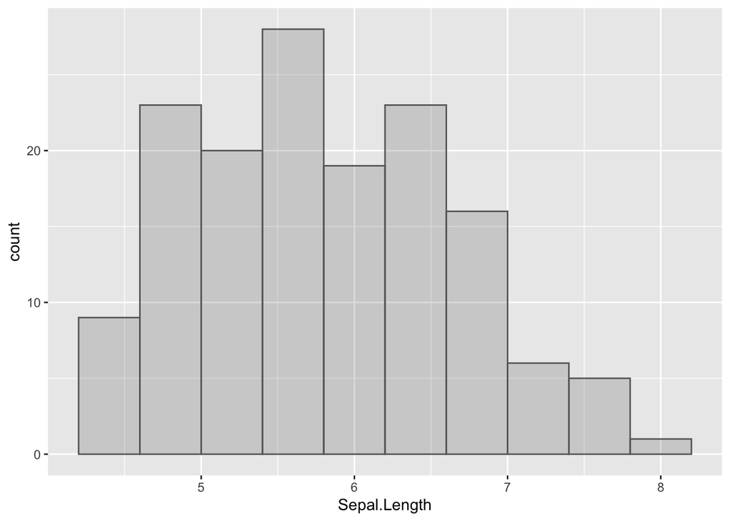

```r
iris %>%
  ggplot(aes(x = Sepal.Length))+
  geom_histogram(position="identity", colour="grey40", alpha=0.2, bins = 10)
```

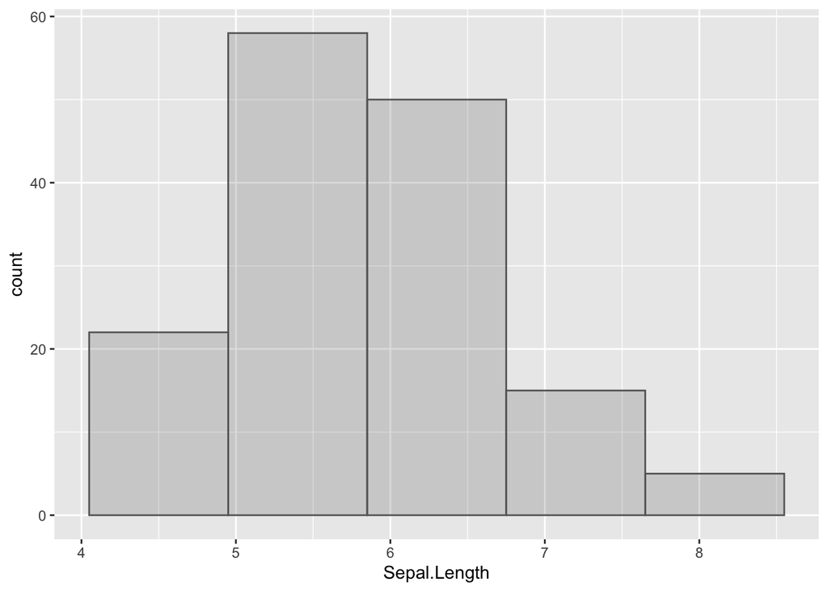

```r
iris %>%
  ggplot(aes(x = Sepal.Length))+
  geom_histogram(position="identity", colour="grey40", alpha=0.2, bins = 5)
```

This gives us more of a grouping around 5-7cm.

*Comments:*  
This is a good choice for graphs, but make sure all graphs have good labels (titles, axes).

## What can you say about the variation of `Sepal.Length` and `Sepal.Width`?

```r
iris %>%
  summarize(SW_mean = mean(Sepal.Width),
            SW_median = median(Sepal.Width),
            SL_mean = mean(Sepal.Length),
            SL_median = median(Sepal.Length))
```

```
##    SW_mean SW_median  SL_mean SL_median
## 1 3.057333         3 5.843333       5.8
```

**Sepal widths** appear to have a normal distribution where widths of ~3.0cm (variance of +-0.5cm) are most common with counts >= 30, whereas there are low counts of sepal widths less than ~2.0cm or greater than ~4.0cm (< 5 counts each).

## 2 :: Examine how the categorical variable `Species` affects the distribution of `Sepal.Length` and `Sepal.Width`. Produce a graph (or two) which shows clearly the relationship you would like to demonstrate.

Sepal Width’s by Species

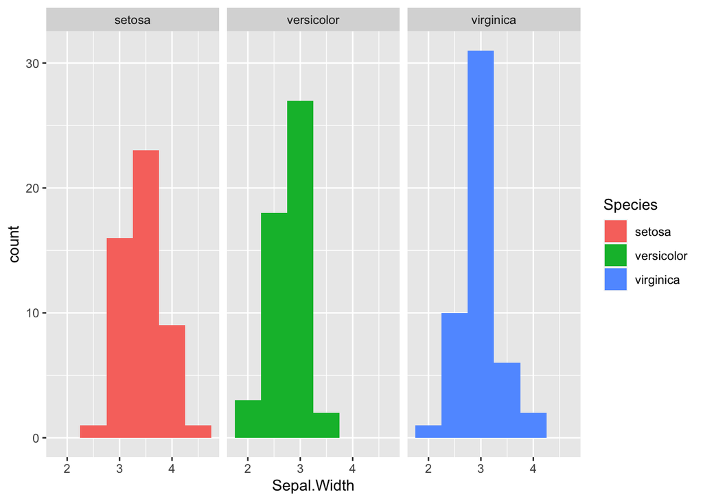

```r
iris %>%
  ggplot() +
  geom_histogram(aes(x = Sepal.Width, fill = Species), binwidth = 0.5) +
  facet_wrap(~Species)
```

Sepal Length’s by Species

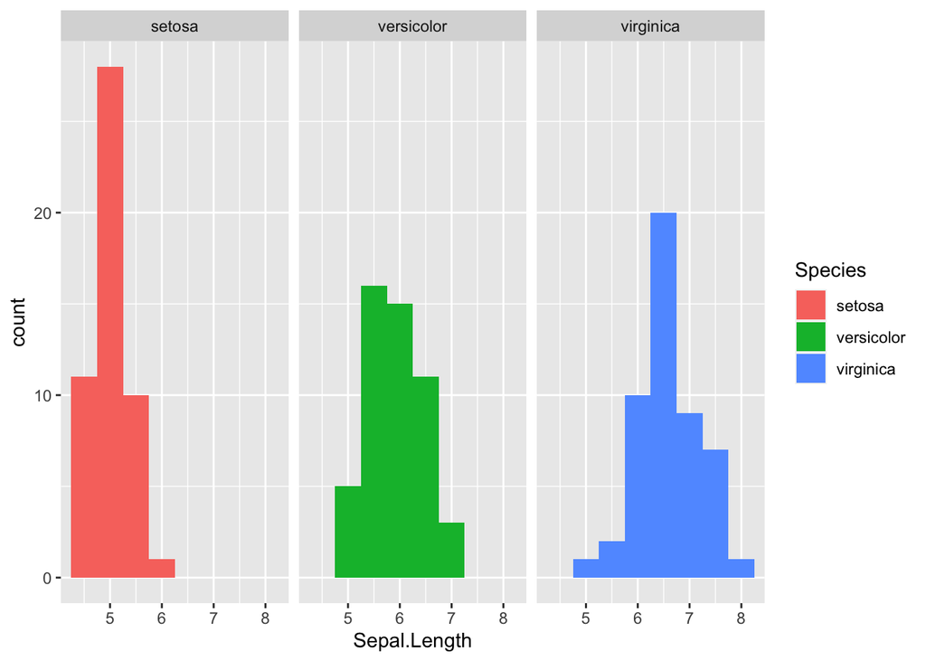

```r
iris %>%
  ggplot() +
  geom_histogram(aes(x = Sepal.Length, fill = Species), binwidth = 0.5) +
  facet_wrap(~Species)
```

## Can the covariation here help explain some of the patterns we saw in first exploration?

*Comments:*  
Nice graphs!

## 3 :: Examine the distribution of `Sepal.Width` now for data in only the species *virginica* in the data set.

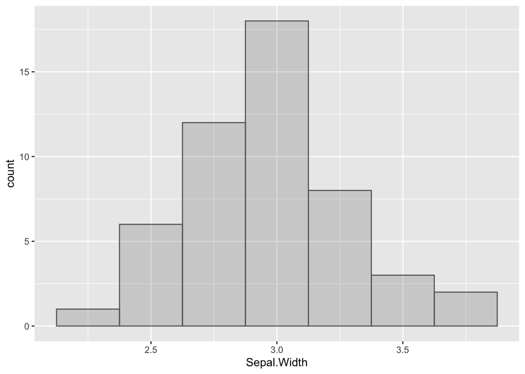

```r
iris %>%
  filter(Species == "virginica") %>%
  ggplot() +
  geom_histogram(colour="grey40", alpha=0.2, aes(x = Sepal.Width), binwidth = 0.25)
```

## What can you say about the distribution?

The distribution has an average of ~3.0cm and is fairly normal.